# Bar Charts in ggplot2

Andy Grogan-Kaylor

2022-07-13

# 1 Background

While `ggplot2`, and the ideas of an underlying *“grammar of graphics”*, make some kinds of graphing easier, `ggplot2` can make other types of graphing more difficult.

One often tricky type of graph is the bar chart. I have come to think that part of the difficulty with thinking about bar charts in `ggplot2` is that sometimes **three very different types of bar charts look similar**.

# 2 Introduction

**Many** bar charts look **something like** the bar chart below.

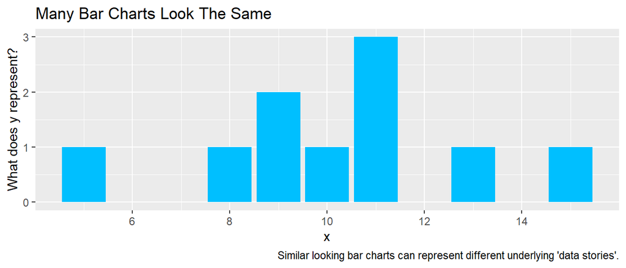

However, there are actually three slightly separate underlying *“grammars of graphics”* that might underlie a bar chart:

1. Bar charts where the height of the bars is the **number of observations** in each category.
2. Bar charts where the height of the bars is the **average value of the y variable** for that category.
3. Bar charts where the height of the bars is the **actual value of the y variable** for that **individual observation**.

Let’s look at each situation in turn, since each situation demands a slightly different syntax.

# 3 Our Data

| x | y |
| --- | --- |
| 1 | 10 |
| 2 | 5 |
| 2 | 9 |
| 3 | 8 |
| 3 | 9 |
| 3 | 10 |

# 4 Bar charts where the height of the bars is the **number of observations** in each category.

```r
library(ggplot2)
```

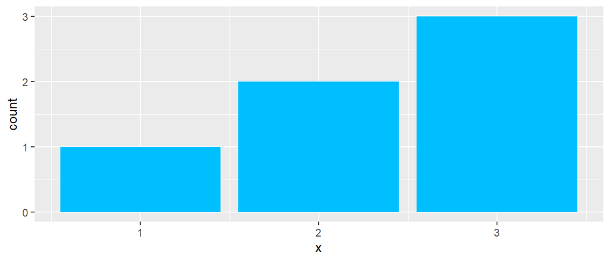

```r
ggplot(mydata, # the data that I am using
       aes(x = x)) + # 'aesthetic' only includes x
  geom_bar(fill = "deepskyblue") # using bars to graph
```

## 4.1 Stacked Bar Chart

A simple change to the above aesthetic yields a stacked bar chart.

Note that *fill* now becomes part of the *aesthetic* so that color fill differentiates the parts of the bar.

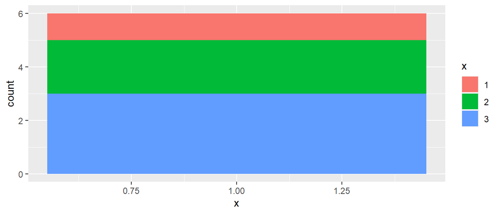

```r
ggplot(mydata, # the data that I am using
       aes(x = 1, # x is 1
           fill = factor(x))) + # fill is x as a factor
  geom_bar() + # using bars to graph
  scale_fill_discrete(name = "x") # modify name of legend
```

> We then return to an unstacked bar chart to consider the syntax for adding labels.

## 4.2 Add Labels

Adding labels requires adding an extra geom, `geom_text`. We have to add a new, non-intuitive aesthetic to `geom_text` to tell it where the labels are located, and that they represent the count of observations in each category. This aesthetic uses the special variable `..count..` to tell us how many observations are in each category.

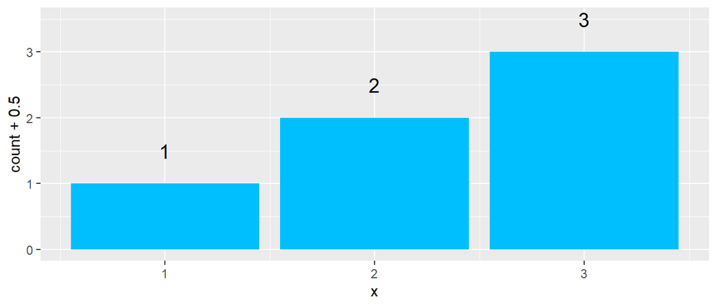

```r
ggplot(mydata, # the data that I am using
       aes(x = x)) + # 'aesthetic' only includes x
  geom_bar(fill = "deepskyblue") + # using bars to graph
  geom_text(stat = "count",
            aes(label = ..count.., # text of the label
                y = ..count.. + .5), # location of the label
            size = 5) # size of the label
```

Alternatively, we could use `..prop..` to calculate and display proportions.

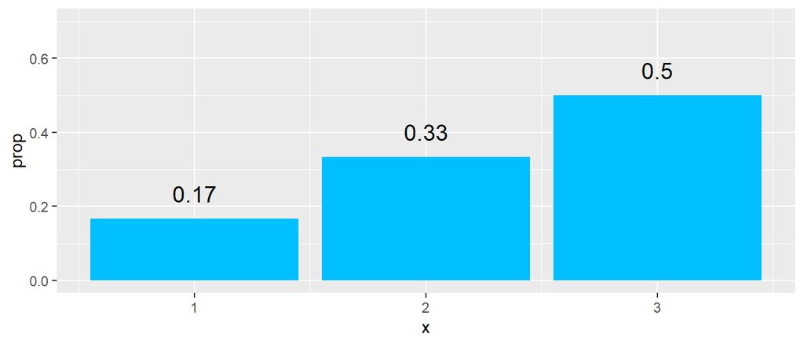

```r
ggplot(mydata, # the data that I am using
       aes(x = x)) +
  geom_bar(aes(y = ..prop..), # using bars to graph
           stat = "count",
           fill = "deepskyblue") +
  geom_text(aes(label = round(..prop.., digits = 2), # text of the label
                y = ..prop.. ), # location of the label
            stat = "count",
            size = 5, # size of the label
            vjust = -1) + # vertical justification
  ylim(0, .7)
```

# 5 Bar charts where the height of the bars is the **average value of the y variable** for that category.

> For this kind of bar chart, we need ask R to summarize the value of `y` for different categories of `x`. The syntax is–shall we say–not very intuitive, but does make sense.

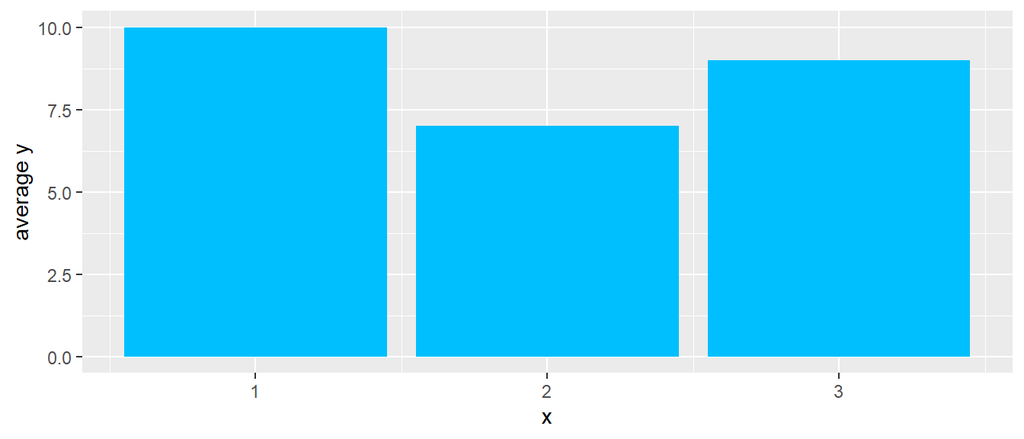

```r
library(ggplot2)

ggplot(mydata, # the data that I am using
       aes(x = x, # 'aesthetic' includes x
           y = y)) + # and y
  stat_summary(fun = mean, # summarizing y
               geom = "bar", # with bars
               fill = "deepskyblue") +
  labs(y = "average y")
```

## 5.1 What About a Line Chart?

A line chart requires the addition of `group` to the aesthetic, and the use of a different geometry.

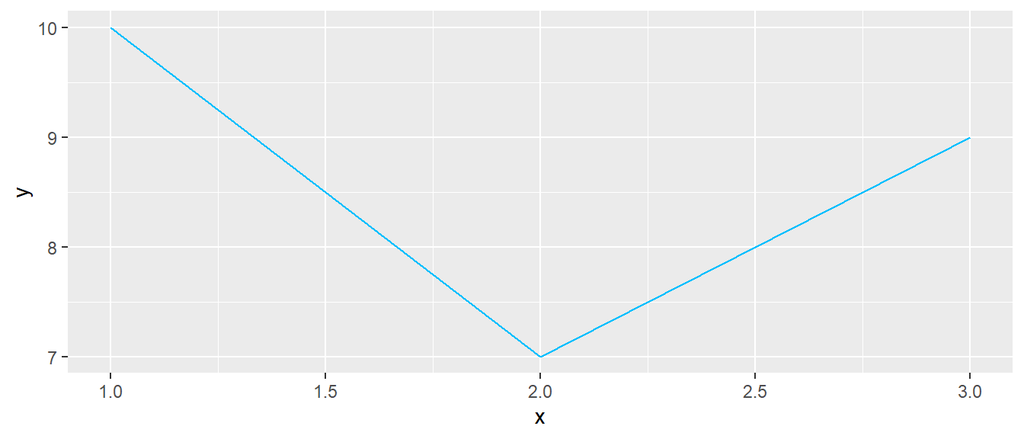

```r
ggplot(mydata, # the data that I am using
       aes(x = x,
           y = y,
           group = 1)) + # add 'group'
   stat_summary(geom = "line", # with line
                fun = mean,
                color = "deepskyblue")
```

# 6 Bar charts where the height of the bars is the **actual value of the y variable** for that category.

Here is where things get complicated. We try something we’ve tried before, but now adding *y* to the aesthetic.

```r
library(ggplot2)

ggplot(mydata, # the data that I am using
       aes(x = x, # 'aesthetic' includes x
           y = y)) + # and y
  geom_bar()
```

This generates the following error message:

> `Error: stat_count() must not be used with a y aesthetic.`

The reason that we are getting this error is that, by default, `geom_bar()` is trying to **count up** the number of *x* values, and in **counting up** the number of *x* values, `geom_bar()` does not know what to do with the *y* value.

So we change this using a different *geometry*, `geom_col()`, whose default behavior is defined to fit this situation: y = height of bars.

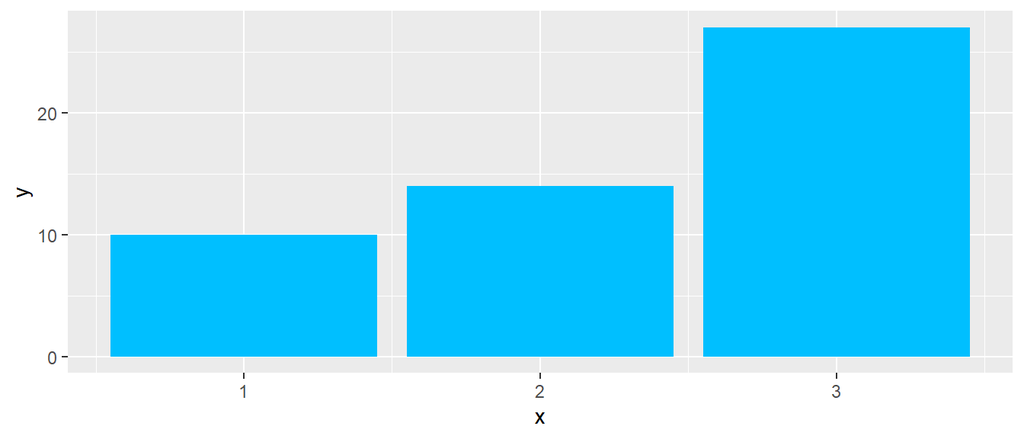

```r
library(ggplot2)

ggplot(mydata, # the data that I am using
       aes(x = x, # 'aesthetic' includes x
           y = y)) + # and y
  geom_col(fill = "deepskyblue") # use ACTUAL y for bar height
```

Alternatively, we could also use `stat = "identity"` within `geom_bar()` to indicate that *y* represents the *actual* height of the bars …

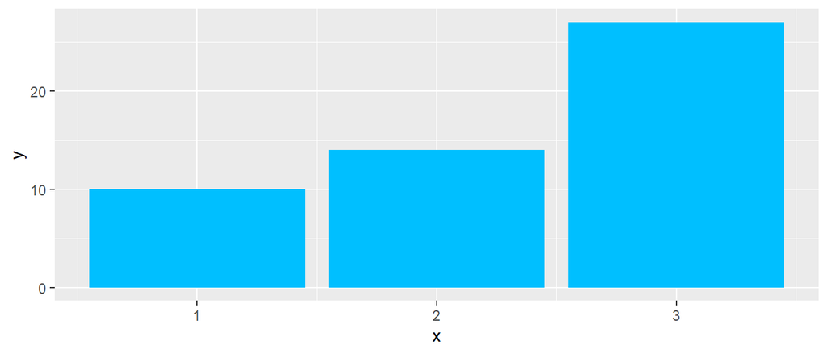

```r
library(ggplot2)

ggplot(mydata, # the data that I am using
       aes(x = x, # 'aesthetic' includes x
           y = y)) + # and y
  geom_bar(stat = "identity",  # use ACTUAL y for bar height
           fill = "deepskyblue")
```

# 7 A Potential Problem

If we go back and look at our data, we remember that we have some duplicate *x*’s,

*1*, *2*, *2*, *3*, *3* and *3*

so some of the bars are actually **over-printing**.

We can see this if we make the bars semi-transparent, and outline the bars with a different color.

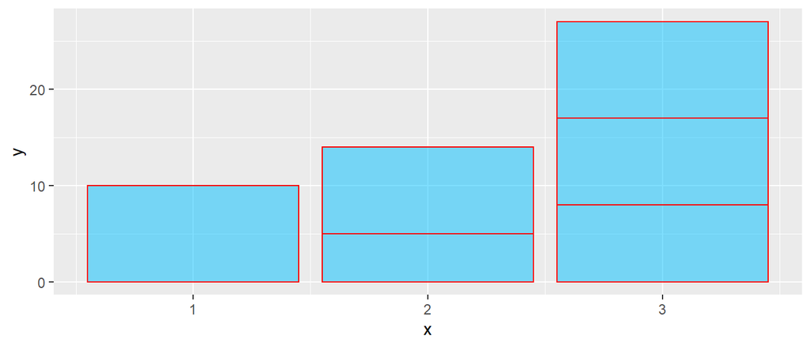

```r
library(ggplot2)

ggplot(mydata, # the data that I am using
       aes(x = x,
           y = y)) + # 'aesthetic' only includes x
  geom_bar(stat="identity", # use ACTUAL y for bar height
           fill = "deepskyblue", # fill
           color = "red", # outline
           alpha = .5) # transparency
```

# 8 Thinking Through The Issue

What is the solution? We may want to go back and look at our data to ensure that if we are using the actual *y* value for the height of the bars that we do **not** have duplicate values of *x* in our data.

**Or**, we may want to have the bars represent the **average value of y** rather than the **actual values of y**, as we did in one of the examples above.

# 9 Of Course The Problem Wouldn’t Come Up If We Had Different Data, Without Those Duplicate *x* Observations

| xREVISED | yREVISED |
| --- | --- |
| 1 | 10 |
| 2 | 5 |
| 3 | 8 |

## 9.1 And Then A Bar Chart Is Easy

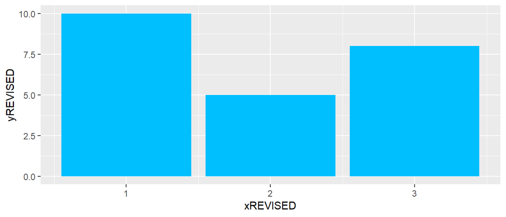

```r
library(ggplot2)

ggplot(mydataREVISED, # the data that I am using
       aes(x = xREVISED, # 'aesthetic' includes x
           y = yREVISED)) + # and y
  geom_bar(stat = "identity", # use ACTUAL y for bar height
           fill = "deepskyblue")
```

## 9.2 A Line Chart Is Easy Too

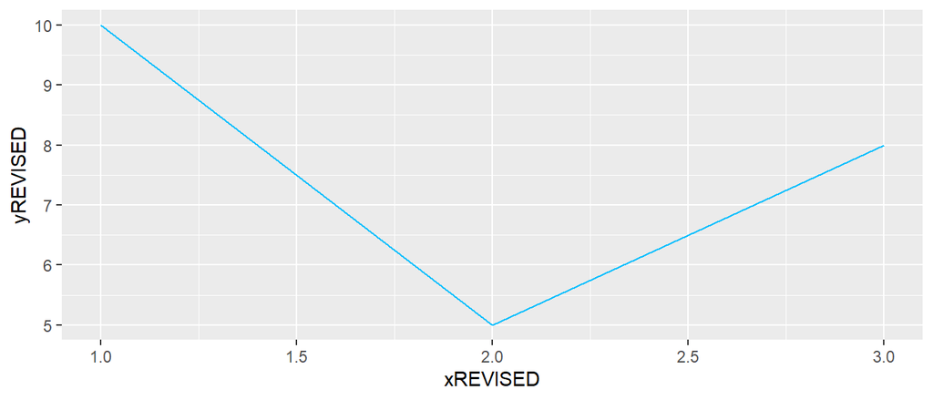

```r
library(ggplot2)

ggplot(mydataREVISED, # the data that I am using
       aes(x = xREVISED, # 'aesthetic' includes x
           y = yREVISED)) + # and y
  geom_line(stat = "identity", # use ACTUAL y for bar height
           color = "deepskyblue")
```

# 10 And Then There Are Pie Charts

In some ways it is confusing, and in some ways it is helpful, that according to the underlying *grammar of graphics* in `ggplot2`, pie charts can be seen as **bar charts that use polar coordinates**. With that in mind, we take some of our earlier code, and add `coord_polar()`.

In the code below, I need to ensure that `ggplot2` sees *x* as a **factor**, and to use *x* as a **fill**. **Fill** is a *crucial* piece of information in a pie chart.

I also need to change `x=` in the `aes`thetic to `1` so that ggplot locates all the slices at the same place in terms of *polar coordinates*.

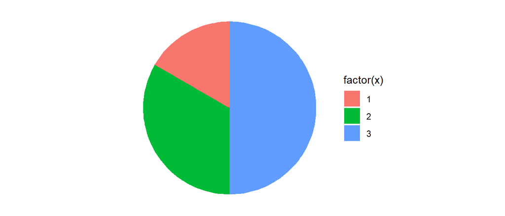

```r
library(ggplot2)

ggplot(mydata, # the data that I am using
       aes(x = 1, # all the slices have the same x
           fill = factor(x))) + # x is now the fill
  geom_bar() + # using bars to graph
  coord_polar(theta = "y") + # polar coordinates
  theme_void() # get rid of distracting numbers
```

> Unfortunately, pie charts are deprecated in some circles, so support for pie charts is not very strong in `ggplot`. It is certainly possible to create a pie chart in `ggplot`, but adding labels to a pie chart ends up being very very difficult.

## 10.1 Pie Chart With Better Colors

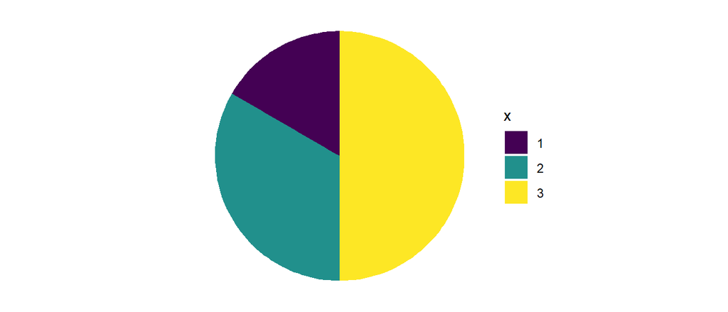

```r
library(ggplot2)

ggplot(mydata, # the data that I am using
       aes(x = 1,
           fill = factor(x))) +
  geom_bar() + # using bars to graph
  coord_polar(theta = "y") + # polar coordinates
  scale_fill_viridis_d(name = "x") + # beautiful colors; named legend
  theme_void() # get rid of distracting numbers
```

# 11 Bar Chart With Better Colors

Up until now, we have had a *minimalist* vision of bar charts, where every bar is the same color, because color would not add **additional information**, over and above the information contained in the position on the *x* axis. However, for the sake of design, we may also choose to add some color to our bar charts. `ggthemes`, `ggthemr` and `viridis` are all ways of adding color to `ggplot` graphs.

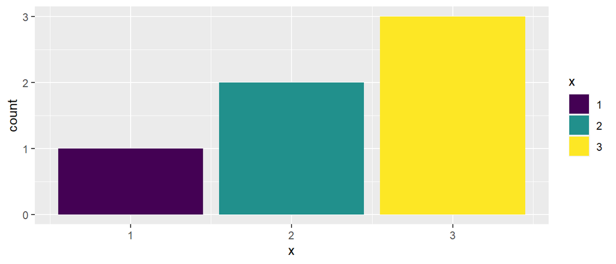

```r
library(ggplot2)

library(viridis) # wonderful colors

ggplot(mydata, # the data that I am using
       aes(x = x, # x is on the x axis
           fill = factor(x))) + # x is also a factor for fill
  geom_bar() + # using bars to graph
  scale_fill_viridis_d(name = "x") # colors; named legend
```

# 12 More Examples

More examples can be found [here](https://agrogan1.github.io/dataviz/how-to-choose-a-chart/how-to-choose-a-chart-v3.html)